[figure not shown]

Análisis Factorial

Confirmatorio

Sesión N°7

Análisis Avanzado de Datos II

Anais Herrera Leighton

[figure not shown]

Medición en Ciencias Sociales

En ocasiones un indicador puede ser suficiente para capturar el concepto que

se quiere medir

Variables observadas (ej. edad, sexo)

Pero algunos conceptos no pueden ser medidos directamente, para lo cual

requerimos distintos indicadores

Variables latentes (ej. Actitudes machistas, clase social)

Medición en Ciencias Sociales

Ejemplo de medición de una variable latente (unidimensional): Escala de

Machismo Sexual (Díaz, Rosas & González, 2010).

Expresa en tu opinión tu grado de acuerdo o desacuerdo con las siguientes frases.

Por favor responde honestamente utilizando estas opciones: (1) Totalmente en

desacuerdo; (2) En desacuerdo; (3) Sin opinión; (4) De acuerdo; (5) Totalmente

de acuerdo

Una mujer debe aceptar las infidelidades de su pareja

El hombre necesita tener varias parejas sexuales

Sin importar la situación o el estado de ánimo, la mujer debe tener relaciones sexuales

cuando su pareja quiera tenerlas

El hombre debe iniciar su vida sexual en la adolescencia

El hombre debe hacer que su hijo hombre inicie su vida sexual

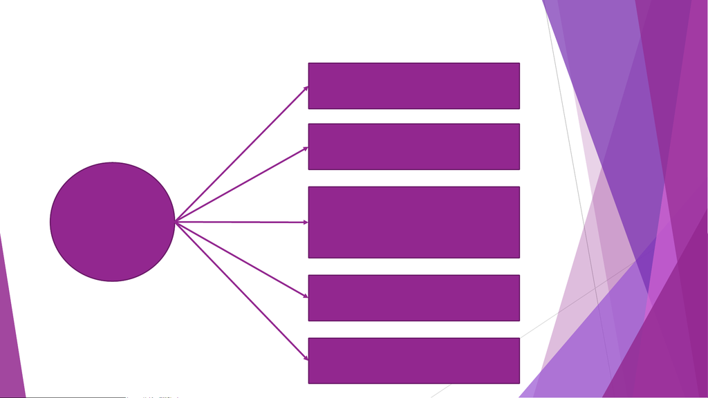

Medición en Ciencias Sociales

Una mujer debe aceptar las

infidelidades de su pareja

Machismo

sexual

El hombre necesita tener varias

parejas sexuales

Sin importar la situación o el

estado de ánimo, la mujer debe

tener relaciones sexuales

cuando su pareja quiera tenerlas

El hombre debe iniciar su vida

sexual en la adolescencia

Medición en Ciencias Sociales

Ejemplos de variables latentes (con más de una dimensión)

Actitudes meritocráticas

Percepciones meritocráticas

Preferencias meritocráticas

Actitudes hacia la violencia de carabineros

Justificación uso de violencia para disolver marchas

Justificación uso de violencia al allanar comunidades mapuche

Inteligencia

Habilidades verbales

Habilidades matemáticas

[figure not shown]

Medición en Ciencias Sociales

Ejemplos de variables latentes (con más de una dimensión): Actitudes meritocráticas (Castillo, Iturra,

Meneses & Maldonado, 2021)

Dimensión

Subdimensión

Indicador

Percepción

Meritocrática

Quienes más se esfuerzan logran obtener mayores recompensas

que quienes se esfuerzan menos.(

i1)

Quienes poseen más talento logran obtener mayores recompensas

que quienes poseen menos talento. (

i2)

No meritocrática

Quienes tienen padres ricos logran salir adelante. (

i3)

Quienes tienen buenos contactos logran salir adelante. (

i4)

Preferencia

Meritocrática

Quienes más se esfuerzan deberían obtener mayores recompensas

que quienes se esfuerzan menos. (

i5)

Quienes poseen más talento deberían obtener mayores

recompensas que quienes poseen menos talento. (

i6)

No meritocrática

Está bien que quienes tienen padres ricos salgan adelante. (

i7)

Está bien que quienes tienen buenos contactos salgan adelante (

i8

)

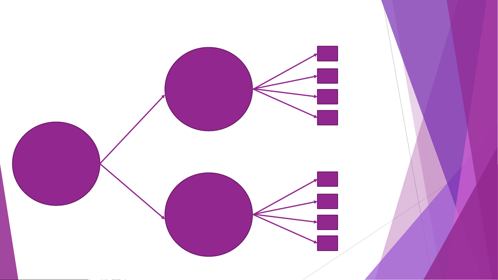

Medición en Ciencias Sociales

i1

Actitudes

meritocráticas

Percepciones

meritocráticas

i2

i3

i4

i5

Preferencias

meritocráticas

i6

i7

i8

Medición en Ciencias Sociales

Los conceptos complejos no se pueden medir directamente, por lo que se realiza

una operacionalización

Variable latente o factor

Generamos mediciones que se aproximan a medir lo que representa el concepto

Variables observadas, indicadores o ítems

No observamos directamente la variable latente, si no que esta es deducida a

partir de las correlaciones entre las variables observadas

Medición de variables latentes

Podemos utilizar modelos estadísticos para entender constructos sociales y

responder preguntas cómo

¿Cómo se relacionan entre sí distintos indicadores de un mismo concepto?

¿Son las variables adecuadas para capturar un determinado concepto?

¿Cuántas dimensiones tiene un concepto?

Análisis factorial (variables continuas)

Permite estudiar la interrelación (o interdependencia) de variables observadas

Se agrupan las variables en un factor o en un número reducido de factores

Cada indicador tiene una varianza común que es explicada por el factor latente y una

varianza única

[figure not shown]

Análisis factorial

Análisis Factorial Exploratorio

(AFE o EFA)

Análisis Factorial Confirmatorio

(AFC o CFA)

Cuando no hay un modelo teórico que

sustenta la manera en que las variables

observadas se relacionan entre sí

Un modelo teórico especifica qué

variables observadas se relacionan con

qué variable(s) latente(s)

Busca identificar las variables latentes

que subyacen a un conjunto de

indicadores correlacionados entre sí

Generalmente, cada variable observada

se relaciona solamente con una

variable latente

El modelo plantea que cada variable

observada se relaciona con todas las

variables latentes

Podemos evaluar si el modelo

planteado se ajusta a los datos

observados

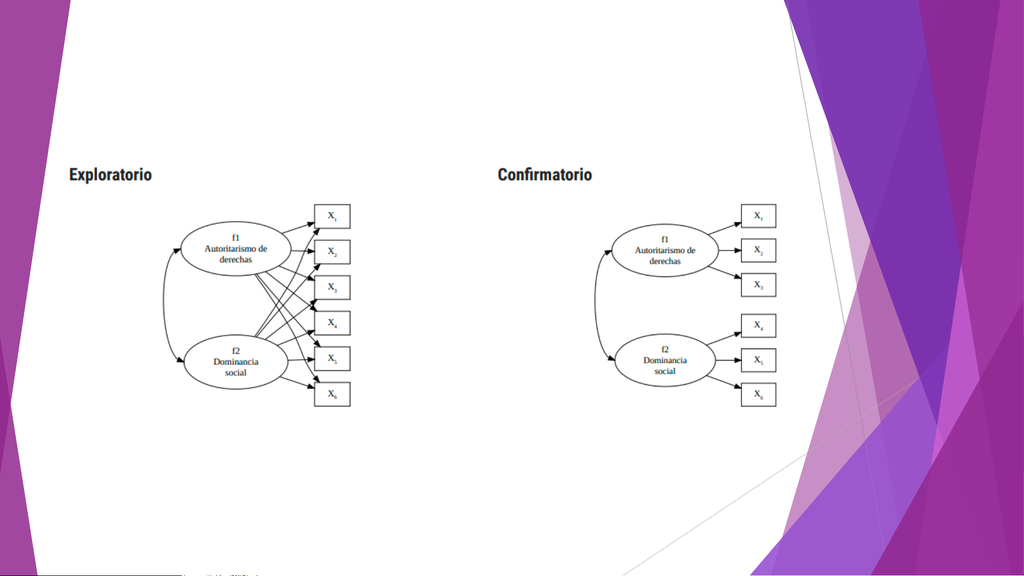

Análisis factorial

¿Corresponden autoritarismo y dominancia a dos dimensiones distintas del

conservadurismo?

Relaciona todos los indicadores

con todos los factores

Restringe relaciones indicadores

y factores

Términos relevantes

Factores: variables latentes a la base de las correlaciones entre los

indicadores

Cargas factoriales: medida estandarizada de asociación entre el indicador y

la variable latente

Comunalidad: proporción del indicador que se asocia a factor(es) comun(es)

Supuestos Análisis Factorial Confirmatorio

Un número importante de variables observadas de nivel de medición

intervalo/razón (mínimo 5 categorías de respuesta en escala).

Base de datos suficientemente grande. Esto depende de la calidad de los

datos, de las correlaciones y del número de ítems. Existen distintos criterios.

En general, utilizar bases de al menos 200 casos.

El modelo está correctamente especificado

Relación lineal entre variables

Ausencia de multicolinealidad

Normalidad multivariante en las variables (al usar el método de estimación de

máxima verosimilitud)

Pasos AFC

1. Identificación modelo

2. Evaluación ajuste del modelo

3. Cargas factoriales y comunalidades

4. Comparación modelos

5. Reespecificar modelo (si es necesario)

[figure not shown]

Estimación del modelo

Utilizaremos el paquete {lavaan} (Rosseel, 2012)

Comenzamos especificando el modelo en un objeto:

El símbolo =~ significa que la variable latente (izquierda) es medida por los

indicadores (derecha)

La función cfa() se usa para estimar el modelo

mod_conf_cfa es un objeto con los resultados del modelo ajustado

mod_conf <- 'autoritarismo =~ aut1 + aut2 + aut3

dominancia =~ dom1 + dom2 + dom3'

mod_conf_cfa <- cfa(mod_conf, # modelo especificado

data = datos) # base de datos con ítems

Evaluación ajuste del modelo

Prueba de Chi-Cuadrado

Evalúa si existen discrepancias significativas entre la matriz de covarianza

observada y la que es estimada por el modelo

La hipótesis nula plantea que no son significativamente distintas

En este caso, p > 0,05 indica un buen ajuste del modelo con 95% de confianza

Buscamos mantener la hipótesis nula

Sin embargo, es sensible al tamaño de la muestra

Con muestras grande (n > 400) es muy difícil encontrar un buen ajuste

Criterio menos estricto: Chi2/ grados de libertad < 2

Aunque hay autores que proponen que si el valor es igual o menor a 4 el ajuste es

adecuado

Evaluación ajuste del modelo

RMSEA (Root Mean Square Error of Approximation)

Evalúa el ajuste del modelo considerando el tamaño de la muestra y la

complejidad del modelo.

Valores menores a 0,05 indican un buen ajuste

Valores entre 0,05 y 0,08 indican un ajuste razonable

Valores sobre 0,10 indican un mal ajuste

Evaluación ajuste del modelo

CFI (Comparative Fit Index)

Índice que compara el ajuste del modelo con un modelo base o nulo (modelo

sin covarianzas entre las variables)

Da cuenta del incremento en el ajuste al pasar de un modelo base al modelo

propuesto

Es menos sensible al tamaño de la muestra

Obtiene valores entre 0 y 1. Mientras más cercano a 1, mejor es el ajuste

En general, se considera que un modelo tiene un ajuste razonable si CFI >

0,90 y que tiene un ajuste bueno si CFI > 0,95.

Cargas factoriales y comunalidades

Estimamos el modelo y obtenemos cargas para cada variable en su factor

correspondiente

Obtenemos soluciones estandarizadas y no estandarizadas

Un buen modelo tiene cargas factoriales estandarizadas sobre 0,7 (o al menos

sobre 0,5)

Recordatorio: las cargas factoriales son una medida estandarizada de

asociación entre el indicador y la variable latente

Las comunalidades corresponden al R-cuadrado, esto es, el porcentaje de

varianza de una variable que es explicado por la variable latente (carga

estandarizada al cuadrado).

Las cargas (y comunalidades) más altas implican que las variables son más

relevantes a la hora de definir un factor (mediciones más “puras” de este)

La información de las cargas sirve para determinar eventualmente que ítem

sería mejor eliminar (si es que es necesario eliminar algún ítem), pudiéndose

descartar la(s) variable(s) con la(s) carga(s) más baja(s).

Cargas factoriales y comunalidades

estandarizadas

aut1 y dom1 igual a 1

Fijado así para dar escala de

los factores

lavaan asume que el primer

indicador de un factor se fija

en 1

Std.lv: solución con factores

estandarizados

Std.all: solución con factores

e indicadores estandarizados

Cargas factoriales y comunalidades

Su relación con los factores

es significativa al 95% de

confianza

aut1 y dom1 no tienen valor p

porque fueron fijados

Los coeficientes

estandarizados (Std.all) > 0,5

Solo dom3 tiene un

coeficiente < 0,7

aut1 y dom1 son los

indicadores más puros de sus

factores

Cargas factoriales y comunalidades

95% de confianza, p<0,05

La correlación entre ambas

variables es positiva (Std.all =

0,343)

Cargas factoriales y comunalidades

Estas se calculan como la carga factorial estandarizada al cuadrado

En general, observamos comunalidades altas.

El ítem dom3 tiene la comunalidad más baja: el factor “dominancia” explica

el 46,9% de la varianza de dom3.

Podríamos evaluar si sacar este ítem del modelo, en caso de querer reducir la

escala

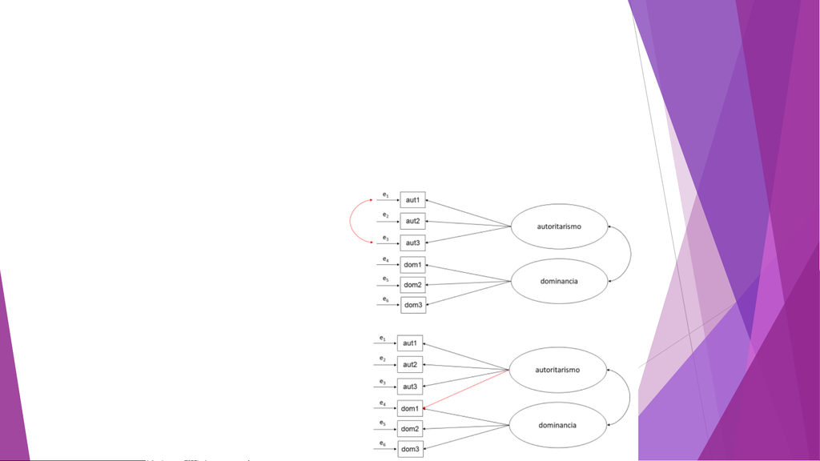

Reespecificar modelo

Eventualmente, si el modelo no ajusta

adecuadamente, se recomienda

considerar índices de modificación

En general, se proponen cambios

relativos a la especificación de:

Correlaciones entre los errores de

indicadores

Implica una asociación indicadores que no

es explicada por la asociación con el

factor, ej.: (a) Indicadores medidos en un

mismo momento en el tiempo o (b)

Indicadores medidos utilizando pruebas

parecidas

Cargas cruzadas: un indicador carga en

más de un factor

En caso de realizarse, debiera ser

justificado teóricamente

Reespecificar modelo

Mayores mi indican que este cambio significará un mayor cambio en la bondad de

ajuste del modelo

=~: indica agregar un efecto de una variable observada en una variable latente

~~: indica agregar una correlación entre los errores de dos variables observadas

sugiere: